# Stationary solution of the cable equation:

# 𝜕2𝑢(𝑥,𝑡)/𝜕𝑥2 − 𝑢(𝑥,𝑡) = −𝑖(𝑥,𝑡)

Use the finite difference method to change this equation to the matrix format as:𝐴̿.𝑢 = 𝑠̅ and solve the equation to find the distribution of the membrane potential using both steepest descent and CG algorithms. (Suppose that the membrane potential is zero, 𝑢(𝑥,𝑡) = 0.0, when 𝑥 = +5 𝑎𝑛𝑑 𝑥 = −5).

Here even u is a function of x and t(space and time respectively) we are only concern about x because t is constant when we are doing differentiation with respect to x only. We are given that 𝑖(𝑥,𝑡) = 𝛿(𝑥), that means when x=0, 𝑖(𝑥,𝑡) = 1 otherwise 0. The finite difference method is a means of solving differential equations numerically by using a finite value for delta x rather than delta x -> 0.

The general equation 2nd order differential equation in terms of finite difference method given by:

### 𝜕2𝑢(𝑥,𝑡)/𝜕𝑥2 = [u(x(i+1),t) - 2u(x(i),t) + u(x(i-1),t) ] / (delta x)^2

So we can break our given 2nd order differential equation into a bunch of linear equations of u to find out the value of u at different nodes. For the shake of simplicity I am taking the number of nodes =11 and delta x=1 and i ={1, ..., 11}

```
|----|----|----|----|----|----|----|----|----|----|
-5   -4   -3   -2   -1   0    1    2    3    4    5
```

Now we will write the linear equation of u at each node. We already know the boundary conditions. So, U1=U(-5,t=0)=0 and U11=U(5,t=0)=0 Now,

[output not shown]

Now we can write the previous bunch on Linear equations in the form of A.x=b format. So it becomes,

```
 [ 1.  0.  0.  0.  0.  0.  0.  0.  0.  0.  0.]   [u1]     [0]
 [ 1. -3.  1.  0.  0.  0.  0.  0.  0.  0.  0.]   [u2]     [0]
 [ 0.  1. -3.  1.  0.  0.  0.  0.  0.  0.  0.]   [u3]     [0]
 [ 0.  0.  1. -3.  1.  0.  0.  0.  0.  0.  0.]   [u4]     [0]
 [ 0.  0.  0.  1. -3.  1.  0.  0.  0.  0.  0.] X [u5]     [0]
 [ 0.  0.  0.  0.  1. -3.  1.  0.  0.  0.  0.]   [u6]  =  [-1]
 [ 0.  0.  0.  0.  0.  1. -3.  1.  0.  0.  0.]   [u7]     [0]
 [ 0.  0.  0.  0.  0.  0.  1. -3.  1.  0.  0.]   [u8]     [0]
 [ 0.  0.  0.  0.  0.  0.  0.  1. -3.  1.  0.]   [u9]     [0]
 [ 0.  0.  0.  0.  0.  0.  0.  0.  1. -3.  1.]   [u10]    [0]
 [ 0.  0.  0.  0.  0.  0.  0.  0.  0.  0.  1.]   [u11]    [0]
```

As, we have constructed our A.x =b format, we can use Steepeset Descent and Conjugate Gradient Algorithm to solve for u at different nodes.

## Steepest Descent:

If we have an equation in A.x=b form, where A is N x N matrix and b, x are N dimensional vectors, Steepest Descent method helps to find the solution for x in a iterative process by implementing line search mechanism repeatedly. In the method of Steepest Descent, we start at an arbitrary point in N dimension, x(0), then we take each step in the direction(residual at that point) where the f decreases most quickly, until we are satisfied that we are close enough to the solution of x. Alpha(α) or step-size in a line search procedure tells us where in the line or direction of the movement the value of f will be minimized. The residual of the current step and the direction of the movement to be taken from the current point is orthogonal to each other. The next value of x is calculated with the Linear Combination of current value of x, Step Size or Alpha and Residual at that point.

```python
N=11 # Number of Nodes
deltaX= 10/(N-1) # Delta X
middle = (-2)- (deltaX*deltaX)
```

```python
import numpy as np
import pandas as pd
import matplotlib.pyplot as plt
```

```python
A=np.zeros((N,N), dtype=float) # Initialization of A Matrix
```

```python
if N%2 ==1:
    odd=1
    center=int(np.ceil(N/2))
else: center=0
```

```python
b=np.zeros((N,1), dtype=float)  # Construction of b vector Dynamically
if center>0:
    b[center-1,0]=-(deltaX*deltaX)
print (b)
```

```
[[ 0.]
 [ 0.]
 [ 0.]
 [ 0.]
 [ 0.]
 [-1.]
 [ 0.]
 [ 0.]
 [ 0.]
 [ 0.]
 [ 0.]]
```

```python
x=np.zeros((N,1), dtype=float) # Initializing x vectors to zeros.
```

```python
A[0,0]=1   # Construction of A Matrix Dynamically
A[N-1,N-1]=1
for i in range(1,N-1):
    start=i-1
    A[i,start]=1
    A[i, start+1]=middle
    A[i,start+2]=1
print (A)
```

```
[[ 1.  0.  0.  0.  0.  0.  0.  0.  0.  0.  0.]
 [ 1. -3.  1.  0.  0.  0.  0.  0.  0.  0.  0.]
 [ 0.  1. -3.  1.  0.  0.  0.  0.  0.  0.  0.]
 [ 0.  0.  1. -3.  1.  0.  0.  0.  0.  0.  0.]
 [ 0.  0.  0.  1. -3.  1.  0.  0.  0.  0.  0.]
 [ 0.  0.  0.  0.  1. -3.  1.  0.  0.  0.  0.]
 [ 0.  0.  0.  0.  0.  1. -3.  1.  0.  0.  0.]
 [ 0.  0.  0.  0.  0.  0.  1. -3.  1.  0.  0.]
 [ 0.  0.  0.  0.  0.  0.  0.  1. -3.  1.  0.]
 [ 0.  0.  0.  0.  0.  0.  0.  0.  1. -3.  1.]
 [ 0.  0.  0.  0.  0.  0.  0.  0.  0.  0.  1.]]
```

```python
iteration=1000    # Maximum Number of Iterations (Arbritary)
r=b-np.dot(A,x)   # Initial Residual
delta= np.dot(r.T, r)[0,0]  # Norm of Residual (How far from the solution).
delta0=delta  # Make a copy od Initial Residual Norm.
i=0
while i<iteration and delta > 0.00000001*delta0 : #Loop will run if current iteration< Max iteration and current residual is above
                                                  #tolerance level
    q=np.dot(A,r)                   # Calculating A*r, which will be used for Alpha and Next r or residual Calculation
    alpha= delta/np.dot(r.T,q)[0,0] # Calculating Alpha or Stepsize. It is a Scaler.
    x=x+(alpha*r)                   # Calculating next x, by taking alpha stepsize in the direction of r or current residual.
    if (i%50)==0:
        r=b-np.dot(A,x)             # Number 50 is arbitrary and this step is to reduce appox. error.
    else:
        r=r-(alpha*q)               # Calculating the new residual, r= r(cur) - (step_size*(A*r(cur)))
    delta=np.dot(r.T, r)[0,0]       # Norm of Just Calculated Residual (How far from the solution).
    i=i+1                           # increase Counter
print (x)
```

```
[[ 0.        ]
 [ 0.00812249]
 [ 0.02438108]
 [ 0.06502077]
 [ 0.17071689]
 [ 0.44712989]
 [ 0.17071689]
 [ 0.06502077]
 [ 0.02438108]
 [ 0.00812249]
 [ 0.        ]]
```

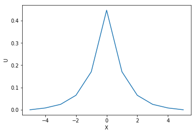

```python
%matplotlib inline
                                    # Plot of Stationary Solution of the Cable Equation with a constant current of unit strength
                                    # injected at x=0
axis_p=np.zeros((N,1), dtype=float)
j=-5
for i in range(N):
    axis_p[i,0]=j
    j=j+deltaX
#print(np.dot(A,x))

plt.plot(axis_p,x)
plt.xlabel('X')
plt.ylabel('U')
```

```python
inverse = np.linalg.inv(A) # Taking Inverse of A
```

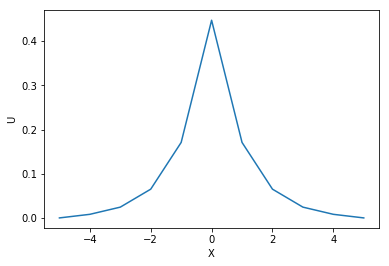

```python
x11=np.dot(inverse,b)  # Direct Solution of x. x=Inv(A) * b and its plot.
x12=np.dot(A,x11)
plt.plot(axis_p,x11)
#print(np.dot(A,np.dot(inverse,b)))
plt.xlabel('X')
plt.ylabel('U')
```

## Conjugate Gradients:

Steepest Descent often finds itself taking steps in the same directions as the earlier steps. The driving idea behind Conjugate Gradients, if we can find a set of Orthogonal Search Directions (d (0), ….., d (n))and in each step towards these directions we will eliminate the error in x in a particular direction, so any Optimization problem can be solved in N(Dimension of the space of x) steps but unfortunately it is not possible because the Error term which we are trying to eliminate is unknown. So, we turn towards the Conjugate directions or A-Orthogonal Directions rather than Orthogonal directions. Now at each step i, e(i+1) is A-Orthogonal to the direction d(i). The main intuition to create N A-Orthogonal Search Directions came from “Gram Schmidt Conjugation” theory. The main intuition of this theory is, if we have N-Linearly Independent vectors, we can create N-A Orthogonal vectors by taking any unused vector from the set of N-Linearly Independent vectors and subtract any components that are not A-Orthogonal to the previous directions or d vectors. Residuals play a major role here. We know that e(i+1) has to be A-Orthogonal to the previous directions (Conjugate Directions), so residual (r= - Ae) at current point is Orthogonal to all the previous search directions and residuals. So if we consider a set of residuals as the set of N-Linearly Independent vectors from “Gram Schmidt Conjugation” method, it is guaranteed to produce a new linearly independent search direction every time. Even we can calculate the next residual from the Linear Combination of Alpha/Step Size (minimizes f along the search direction), A and the previous direction of movement or search direction.

```python
x_c=np.zeros((N,1), dtype=float) # Initializing x to zeros.
iterations=1000                  # Setting Maximum number of iterations. Arbritrary
#epsilon = np.power(10.0,-4)
r_c=b-np.dot(A,x_c)             # Calculating Initial Residual
d_c=r_c                         # Setting initial direction as residual.
delta_new= np.dot(r_c.T, r_c)[0,0] # Calculating magnitude of initial residual.
delta0_c=delta_new                 # Make a copy od Initial Residual Norm.
i=0
while i<iterations and delta_new > 0.000001*delta0_c : #Loop will run if current iteration< Max iteration and current
                                                       #residual is above tolerance level
    q_c = np.dot(A,d_c)          # Calculating A*direction, which will be used for next x, Alpha and Next r or residual Calculation
    alpha_c=delta_new/np.dot(d_c.T,q_c)[0][0] # Calculating Alpha or Stepsize. It is a Scaler.
    x_c=x_c+(alpha_c*d_c)   # Calculating next x, by taking alpha stepsize in the direction of movement.
    if (i%50)==0:
        r_c=b-np.dot(A,x_c)   # Number 50 is arbitrary and this step is to reduce appox. error.
    else:
        r_c=r_c-(alpha_c*q_c)  # Calculating the new residual, r= r(cur) - (step_size*(A*d(cur)))
    delta_old=delta_new        # backup currrent delta, Residual Norm
    delta_new= np.dot(r_c.T, r_c)[0,0]  # Norm of Just Calculated Residual (How far from the solution).
    beta=delta_new/delta_old            # Beta calculation, will be used to substract the components from r
                                        #which are not A-Orthogonal to previous Search directions
    d_c= r_c+ (beta*d_c)                # Calculation of new direction which is A-Orthogonal to all previous directions.
    #print (i)
    i=i+1                               # Counter increment
```

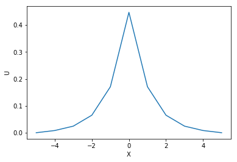

```python
axis_c=np.zeros((N,1), dtype=float) # Plot of Stationary Solution of the Cable Equation with a constant current of unit strength
                                    # injected at x=0
j=-5
for i in range(N):
    axis_c[i,0]=j
    j=j+deltaX
#print(np.dot(A,x))

plt.plot(axis_c,x_c)
plt.xlabel('X')
plt.ylabel('U')
```

```python
np.all(np.linalg.eigvals(A) > 0) #Eigen Value checking
```

```
False
```

```python
np.linalg.eigvals(A) #Eigen Values
```

```
array([-4.90211303, -4.61803399, -4.1755705 , -3.61803399, -3.        ,
       -1.09788697, -1.38196601, -2.38196601, -1.8244295 ,  1.        ,  1.        ])
```